# Brain Tumor — Feature Parameter Selection + Benchmark

## Phase 1: Optimal GLCM · LBP · DWT · HOG parameters via Class-Separability Metrics

## Phase 2: SVM · KNN · RF · XGBoost · LightGBM · LR · MLP · ExtraTrees Benchmark

### Strategy

Training a full classifier for every parameter combination is expensive. Instead we use three **classifier-free separability metrics** to score each feature configuration in seconds:

| Metric | What it measures | Why useful |
| --- | --- | --- |
| **Fisher's Discriminant Ratio (FDR)** | Between-class variance ÷ within-class variance per feature (averaged) | High FDR = features naturally cluster by class |
| **Mutual Information (MI)** | Statistical dependency between each feature and the class label | Captures non-linear relationships |
| **Davies-Bouldin Index (DBI)** | Cluster compactness & separation in feature space | Lower = better separated classes |

Once the best parameters are selected, a single model benchmark is run with those parameters.

### Parameters explored

| Feature | Parameters |
| --- | --- |
| **GLCM** | distances, angles, levels, symmetric |
| **LBP** | P (sampling points), R (radius), method |
| **DWT** | wavelet family, decomposition levels |
| **HOG** | orientations, pixels per cell, cells per block, block norm |

## 1. Setup

```python
# Run once when setting up the env, then RESTART THE KERNEL before imports.
# Re-running pip without restart can break scipy/sklearn (AttributeError on scipy.sparse.linalg).
%pip install -q numpy pandas matplotlib seaborn scikit-learn scikit-image scipy pywavelets tqdm pillow joblib gdown xgboost lightgbm
print("If packages were installed or upgraded: Kernel → Restart, then run from §1 imports onward (skip this cell).")
```

```
If packages were installed or upgraded: Kernel → Restart, then run from §1 imports onward (skip this cell).
```

```python
import time, warnings, itertools, hashlib
import joblib
import numpy as np
import pandas as pd
import matplotlib.pyplot as plt
import matplotlib.gridspec as gridspec
import seaborn as sns
from tqdm.auto import tqdm
from pathlib import Path

from scipy.stats import skew, kurtosis

from sklearn.preprocessing import StandardScaler, label_binarize, MinMaxScaler
from sklearn.model_selection import train_test_split, StratifiedKFold, GridSearchCV
from sklearn.feature_selection import mutual_info_classif, VarianceThreshold
from sklearn.metrics import (accuracy_score, f1_score, precision_score,
                             recall_score, confusion_matrix, davies_bouldin_score,
                             silhouette_score)
from sklearn.decomposition import PCA
from sklearn.pipeline import Pipeline
from sklearn.svm import SVC
from sklearn.neighbors import KNeighborsClassifier
from sklearn.ensemble import RandomForestClassifier, ExtraTreesClassifier, VotingClassifier
from sklearn.linear_model import LogisticRegression
from sklearn.neural_network import MLPClassifier
from xgboost import XGBClassifier
from lightgbm import LGBMClassifier

from skimage.io import imread
from skimage.color import rgb2gray
from skimage.transform import resize
from skimage.filters import gaussian
from skimage import exposure
from skimage.feature import hog, local_binary_pattern, graycomatrix, graycoprops
import pywt

warnings.filterwarnings("ignore")
SEED = 42
np.random.seed(SEED)
sns.set_theme(style="whitegrid", font_scale=1.05)

print("All imports OK.")
```

```
All imports OK.
```

## 2. Configuration

Edit the parameter grids here to control which values are explored.

```python
from pathlib import Path

# ── Dataset (download §0 → ./Dataset) ─────────────────────────────────────
DATASET_BASE = Path("Dataset")

def resolve_images_by_class(base: Path = DATASET_BASE) -> Path:
    candidates = [
        base / "images_by_class",
        base / "Dataset/BrainTumorDetection&Classification/BrainTumorDetection&Classification/images_by_class",
        base / "BrainTumorDetection&Classification/BrainTumorDetection&Classification/images_by_class",
        Path("Dataset-20260515T090034Z-3-001/Dataset/BrainTumorDetection&Classification/BrainTumorDetection&Classification/images_by_class"),
    ]
    for path in candidates:
        if path.is_dir():
            return path
    found = sorted(p for p in base.rglob("images_by_class") if p.is_dir())
    if found:
        return found[0]
    raise FileNotFoundError(
        f"No images_by_class under {base.resolve()}. Run the §0 download cell first."
    )

DATASET_DIR = resolve_images_by_class()
DATASET_ROOT = DATASET_DIR.parent
print(f"Using dataset: {DATASET_DIR}")
TARGET_SIZE  = (128, 128)
USE_CLAHE    = True
TEST_SIZE    = 0.20
MAX_SAMPLES_PER_CLASS = None   # set e.g. 400 for faster runs

# ── Local cache (faster reruns) ───────────────────────────────────────────
CACHE_DIR = Path("cache/brain_tumor")
CACHE_DIR.mkdir(parents=True, exist_ok=True)
FORCE_RECOMPUTE_CACHE = False

# Fine-grained checkpoint folders (phase / cell level)
PHASE_CACHE_DIR = CACHE_DIR / "phase_artifacts"
CELL_CACHE_DIR = CACHE_DIR / "cell_artifacts"
PHASE_CACHE_DIR.mkdir(parents=True, exist_ok=True)
CELL_CACHE_DIR.mkdir(parents=True, exist_ok=True)

# Toggle to reuse saved outputs for heavy cells
USE_PHASE_CACHE = True

# Phase 1 bundle (run Phase 2 in a fresh kernel without re-scanning grids)
PHASE1_BUNDLE_PATH = PHASE_CACHE_DIR / "phase1_bundle.joblib"
PHASE1_HISTORY_PATH = PHASE_CACHE_DIR / "phase1_runs.csv"
PHASE1_MANIFEST_PATH = PHASE_CACHE_DIR / "phase1_runs_manifest.csv"
PHASE1_BEST_JSON_PATH = PHASE_CACHE_DIR / "phase1_best.json"
PHASE1_FULL_SEARCH_DIR = PHASE_CACHE_DIR / "phase1_full_search_archive"
PHASE1_APPEND_FULL_SEARCH_HISTORY = True      # append glcm/lbp/dwt/hog scan tables with run_id (concatenate across runs)
PHASE1_SKIP_IF_OUTCOME_UNCHANGED = True       # skip bundle/history/manifest/archives if best+scores digest matches last manifest row
SKIP_PHASE1_SCANS_IF_BUNDLE_MATCHES = True    # skip GLCM–HOG loops when input fingerprint matches bundle on disk
PHASE1_SKIP_DUPLICATE_HISTORY_ROWS = True    # skip duplicate row in phase1_runs.csv if outcome_hash already logged there
LOAD_PHASE1_BUNDLE_FOR_PHASE2 = True        # True after restart: load BEST_* from disk (run imports→config→data→extractors→bundle cell)

PHASE1_FULL_SEARCH_DIR.mkdir(parents=True, exist_ok=True)
PHASE1_SCAN_CACHE_DIR = PHASE_CACHE_DIR / "phase1_scans"
PHASE1_SCAN_CACHE_DIR.mkdir(parents=True, exist_ok=True)
USE_PHASE1_SCAN_CACHE = True       # save/load each GLCM/LBP/DWT/HOG grid search separately
FORCE_PHASE1_RESCAN = False        # True = ignore per-scan caches and re-run all grids
RUN_PHASE1_VIZ = True             # True = plot top-10 configs per feature (slow on reruns)


# ── Output directory for all figures ───────────────────────────────────────
OUTPUT_DIR = Path("output")
OUTPUT_DIR.mkdir(exist_ok=True)

# ══════════════════════════════════════════════════════════════════════════
# PARAMETER GRIDS — edit these to explore different values
# ══════════════════════════════════════════════════════════════════════════

# ── GLCM parameters ───────────────────────────────────────────────────────
# distances : pixel offsets — small distances capture fine texture,
#             large distances capture coarser structure
# angles    : directions to compute co-occurrence (radians)
# levels    : number of grey-level bins (higher = finer but noisier)
# symmetric : whether to average P(i,j) with P(j,i)
GLCM_GRID = {
    "distances": [
        [1],
        [1, 2],
        [1, 2, 4],
        [1, 2, 4, 8],
        [2, 4],
        [4, 8],
    ],
    "angles": [
        [0],
        [0, np.pi/2],
        [0, np.pi/4, np.pi/2, 3*np.pi/4],          # standard 4 angles
        [0, np.pi/6, np.pi/3, np.pi/2, 2*np.pi/3, 5*np.pi/6],  # 6 angles
    ],
    "levels": [64, 128, 256],
    "symmetric": [True, False],
}

# ── LBP parameters ────────────────────────────────────────────────────────
# P      : number of sampling points around each pixel
#          more points = finer texture description, longer vector
# R      : radius of the circular neighbourhood in pixels
# method : "uniform"     — only patterns with ≤2 bit transitions (compact)
#          "nri_uniform" — non-rotation-invariant uniform patterns
#          "ror"         — rotation-invariant but not uniform
#          "default"     — standard LBP (all 2^P patterns)
LBP_GRID = {
    "P": [8, 12, 16, 24],
    "R": [1, 2, 3],
    "method": ["uniform", "nri_uniform", "ror"],
}

# ── DWT parameters ────────────────────────────────────────────────────────
# wavelet : wavelet family — affects smoothness and frequency localisation
#   haar  : simplest, discontinuous
#   db1-4 : Daubechies family (db1 = haar); more vanishing moments = smoother
#   sym2  : Symlets (near-symmetric Daubechies)
#   coif1 : Coiflets (higher vanishing moments, good for smooth signals)
#   bior1.3: Biorthogonal (symmetric, used in JPEG 2000)
# level   : decomposition depth — more levels = coarser frequency bands
#           but sub-bands become very small on 128×128 images (max ~5 levels)
DWT_GRID = {
    "wavelet": ["haar", "db1", "db2", "db4", "sym2", "coif1", "bior1.3"],
    "level":   [1, 2, 3],
}

# ── HOG parameters ────────────────────────────────────────────────────────
# orientations    : number of gradient direction bins
# pixels_per_cell : spatial granularity of local histograms
# cells_per_block : normalization neighborhood size
# block_norm      : block normalization strategy
HOG_GRID = {
    "orientations": [6, 9, 12],
    "pixels_per_cell": [(8, 8), (16, 16)],
    "cells_per_block": [(2, 2), (3, 3)],
    "block_norm": ["L2-Hys"],
}

# Count total configurations
n_glcm = (len(GLCM_GRID["distances"]) * len(GLCM_GRID["angles"]) *
           len(GLCM_GRID["levels"])    * len(GLCM_GRID["symmetric"]))
n_lbp  = len(LBP_GRID["P"]) * len(LBP_GRID["R"]) * len(LBP_GRID["method"])
n_dwt  = len(DWT_GRID["wavelet"]) * len(DWT_GRID["level"])
n_hog  = (len(HOG_GRID["orientations"]) * len(HOG_GRID["pixels_per_cell"]) *
          len(HOG_GRID["cells_per_block"]) * len(HOG_GRID["block_norm"]))

print(f"GLCM configurations : {n_glcm}")
print(f"LBP  configurations : {n_lbp}")
print(f"DWT  configurations : {n_dwt}")
print(f"HOG  configurations : {n_hog}")
print(f"Total feature configs: {n_glcm + n_lbp + n_dwt + n_hog}")
```

```
Using dataset: Dataset\BrainTumorDetection&Classification\BrainTumorDetection&Classification\images_by_class
GLCM configurations : 144
LBP  configurations : 36
DWT  configurations : 21
HOG  configurations : 12
Total feature configs: 213
```

## 3. Preprocessing & Data Loading

```
Loading dataset from cache: cache\brain_tumor\dataset_3a3180af56.npz
Classes (3): ['Glioma', 'Meningioma', 'Pituitary Tumor']
Train: (1200, 128, 128)   Test: (300, 128, 128)
```

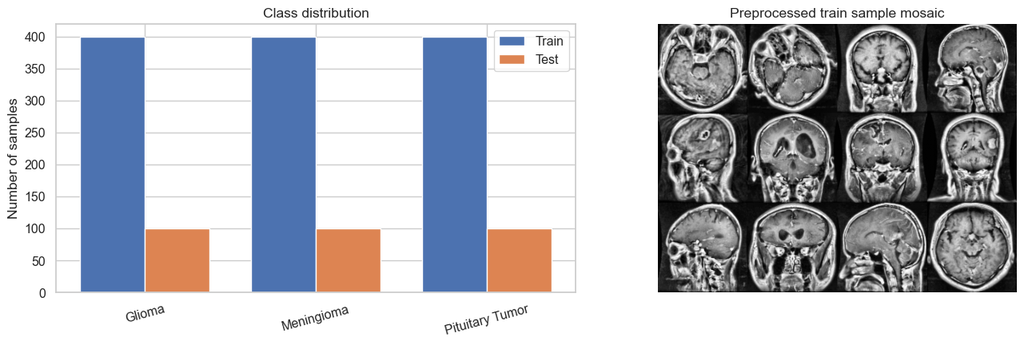

```python
def crop_black(img, thr=0.05):
    mask = img > thr
    if not np.any(mask): return img
    ys, xs = np.where(mask)
    return img[ys.min():ys.max()+1, xs.min():xs.max()+1]

def preprocess_mri(img):
    if img.ndim == 3: img = rgb2gray(img)
    img = img.astype(np.float32)
    if img.max() > 1.0: img /= 255.0
    img = crop_black(img)
    img = resize(img, TARGET_SIZE, anti_aliasing=True, preserve_range=True).astype(np.float32)
    img = gaussian(img, sigma=0.5, preserve_range=True).astype(np.float32)
    mn, mx = img.min(), img.max()
    img = (img - mn) / (mx - mn + 1e-9)
    if USE_CLAHE:
        img = np.clip(exposure.equalize_adapthist(img, clip_limit=0.02), 0, 1)
    return img.astype(np.float32)

def load_dataset(dataset_dir, max_per_class=None):
    class_names = sorted([d.name for d in dataset_dir.iterdir() if d.is_dir()])
    rng = np.random.default_rng(SEED)
    X_list, y_list = [], []
    for idx, cls in enumerate(class_names):
        paths = [p for p in (dataset_dir/cls).iterdir()
                 if p.suffix.lower() in {".jpg",".jpeg",".png",".bmp"}]
        if max_per_class and len(paths) > max_per_class:
            paths = [paths[i] for i in rng.choice(len(paths), max_per_class, replace=False)]
        for p in tqdm(paths, desc=f"  {cls}"):
            try:
                X_list.append(preprocess_mri(imread(p)))
                y_list.append(idx)
            except Exception: pass
    return np.stack(X_list).astype(np.float32), np.array(y_list, np.int32), class_names

cache_tag = f"sz{TARGET_SIZE[0]}x{TARGET_SIZE[1]}_clahe{int(USE_CLAHE)}_test{TEST_SIZE}_max{MAX_SAMPLES_PER_CLASS}"
cache_hash = hashlib.md5(cache_tag.encode("utf-8")).hexdigest()[:10]
dataset_cache_path = CACHE_DIR / f"dataset_{cache_hash}.npz"

if dataset_cache_path.exists() and not FORCE_RECOMPUTE_CACHE:
    print(f"Loading dataset from cache: {dataset_cache_path}")
    ds = np.load(dataset_cache_path, allow_pickle=True)
    X_train_raw = ds["X_train_raw"]
    X_test_raw = ds["X_test_raw"]
    y_train = ds["y_train"]
    y_test = ds["y_test"]
    class_names = list(ds["class_names"])
    X_all = np.concatenate([X_train_raw, X_test_raw], axis=0)
    y_all = np.concatenate([y_train, y_test], axis=0)
else:
    print("Loading dataset from images …")
    X_all, y_all, class_names = load_dataset(DATASET_DIR, MAX_SAMPLES_PER_CLASS)
    X_train_raw, X_test_raw, y_train, y_test = train_test_split(
        X_all, y_all, test_size=TEST_SIZE, random_state=SEED, stratify=y_all
    )
    np.savez_compressed(
        dataset_cache_path,
        X_train_raw=X_train_raw,
        X_test_raw=X_test_raw,
        y_train=y_train,
        y_test=y_test,
        class_names=np.array(class_names, dtype=object),
    )
    print(f"Saved dataset cache: {dataset_cache_path}")

n_classes = len(class_names)

print(f"Classes ({n_classes}): {class_names}")
print(f"Train: {X_train_raw.shape}   Test: {X_test_raw.shape}")

# ── Dataset plotting: class distribution + sample images ─────────────────
train_counts = np.bincount(y_train, minlength=n_classes)
test_counts = np.bincount(y_test, minlength=n_classes)

fig, axes = plt.subplots(1, 2, figsize=(14, 4.5))
x = np.arange(n_classes)
width = 0.38
axes[0].bar(x - width / 2, train_counts, width=width, label="Train")
axes[0].bar(x + width / 2, test_counts, width=width, label="Test")
axes[0].set_xticks(x)
axes[0].set_xticklabels(class_names, rotation=15)
axes[0].set_title("Class distribution")
axes[0].set_ylabel("Number of samples")
axes[0].legend()

n_show = min(12, len(X_train_raw))
idx = np.random.choice(len(X_train_raw), size=n_show, replace=False)
grid_rows, grid_cols = 3, 4
sample_fig = np.zeros((TARGET_SIZE[0] * grid_rows, TARGET_SIZE[1] * grid_cols), dtype=np.float32)
for k, i in enumerate(idx):
    r, c = divmod(k, grid_cols)
    y0, y1 = r * TARGET_SIZE[0], (r + 1) * TARGET_SIZE[0]
    x0, x1 = c * TARGET_SIZE[1], (c + 1) * TARGET_SIZE[1]
    sample_fig[y0:y1, x0:x1] = X_train_raw[i]
axes[1].imshow(sample_fig, cmap="gray")
axes[1].set_title("Preprocessed train sample mosaic")
axes[1].axis("off")

plt.tight_layout()
plt.show()
```

## 4. Class-Separability Metrics

### Why not just use a classifier?

Training even a simple KNN on every parameter combination would take hours. These three metrics evaluate feature quality in **milliseconds** by directly measuring how well the feature distributions separate the classes.

```
Fisher's Discriminant Ratio (FDR)
  = mean over all features of:
      (between-class variance) / (within-class variance + ε)

  → High FDR means class means are far apart relative to within-class spread
  → Equivalent to the numerator of LDA's objective function

Mutual Information (MI)
  = average MI(feature_i ; class_label) over all features
  → Captures non-linear relationships that FDR misses
  → Scale-invariant — robust to feature magnitude differences

Davies-Bouldin Index (DBI)  [lower = better]
  = average ratio of (within-cluster scatter) to (between-cluster distance)
    computed in the full feature space (using PCA to 20 dims for speed)
  → Directly measures cluster quality in feature space
  → Lower DBI = more compact, better-separated class clusters
```

```python
def fisher_discriminant_ratio(X, y):
    # Compute the mean Fisher Discriminant Ratio across all features.
    # FDR = between-class variance / within-class variance.
    # A higher value means features separate classes better.
    classes = np.unique(y)
    grand_mean = X.mean(axis=0)
    n_features = X.shape[1]

    between = np.zeros(n_features)
    within  = np.zeros(n_features)

    for c in classes:
        Xc = X[y == c]
        n_c = len(Xc)
        class_mean = Xc.mean(axis=0)
        # Between-class: weighted distance of class mean from grand mean
        between += n_c * (class_mean - grand_mean) ** 2
        # Within-class: variance of samples inside this class
        within  += ((Xc - class_mean) ** 2).sum(axis=0)

    # Avoid division by zero with a small epsilon
    fdr_per_feature = between / (within + 1e-10)
    return float(np.mean(fdr_per_feature))


def mutual_information_score(X, y):
    # Average mutual information between each feature and the class label.
    # Uses sklearn's implementation which handles discrete classes automatically.
    # Returns a scalar: higher = features carry more information about the label.
    mi = mutual_info_classif(X, y, random_state=SEED, n_neighbors=5)
    return float(np.mean(mi))


def davies_bouldin(X, y, max_dim=20):
    # Davies-Bouldin Index on a PCA-reduced version of X.
    # Lower = better separated classes.
    # We reduce to max_dim components first for speed (avoids O(n²) in high-D).
    n_comp = min(max_dim, X.shape[1], X.shape[0] - 1)
    Xr = PCA(n_components=n_comp, random_state=SEED).fit_transform(X)
    return float(davies_bouldin_score(Xr, y))


def evaluate_features(X, y, label="", verbose=False):
    # Apply all three metrics; return a dict.
    # X should already be standardised for fair comparison across configs.
    sc  = StandardScaler()
    Xs  = sc.fit_transform(X)
    fdr = fisher_discriminant_ratio(Xs, y)
    mi  = mutual_information_score(Xs, y)
    dbi = davies_bouldin(Xs, y)
    if verbose:
        print(f"  {label:40s}  FDR={fdr:.4f}  MI={mi:.4f}  DBI={dbi:.4f}")
    return {"FDR": fdr, "MI": mi, "DBI": dbi}


# Quick sanity-check on a dummy random feature matrix
_X_dummy = np.random.randn(len(y_train), 20)
_res = evaluate_features(_X_dummy, y_train, "random baseline", verbose=True)
print("Sanity check passed — metrics computed successfully.")
```

```
  random baseline                           FDR=0.0016  MI=0.0070  DBI=32.8890
Sanity check passed — metrics computed successfully.
```

## 5. Parameterised Feature Extraction Functions

```python
# ── GLCM extractor (fully parameterised) ──────────────────────────────────
def extract_glcm(images, distances, angles, levels, symmetric):
    # Compute GLCM-based texture features for a list of images.
    # distances : list of pixel offsets
    # angles    : list of angles in radians
    # levels    : number of grey-level bins
    # symmetric : whether to symmetrise the co-occurrence matrix
    #
    # Returns one row per image with 6 GLCM properties averaged over all
    # (distance, angle) pairs.
    props = ["contrast","dissimilarity","homogeneity","energy","correlation","ASM"]
    rows = []
    for img in images:
        # Quantize to [0, levels-1] so graycomatrix(levels=...) is valid.
        q = np.clip(np.floor(img * levels), 0, levels - 1).astype(np.uint8)
        glcm = graycomatrix(q, distances=distances, angles=angles,
                            levels=levels, symmetric=symmetric, normed=True)
        row = [graycoprops(glcm, p).mean() for p in props]
        rows.append(row)
    return np.array(rows, dtype=np.float32)


# ── LBP extractor (fully parameterised) ───────────────────────────────────
def extract_lbp(images, P, R, method):
    # Compute LBP histogram features for a list of images.
    # P      : number of circularly-symmetric neighbour set points
    # R      : radius of circle
    # method : LBP variant — affects number of unique patterns
    #   "uniform"     → P+2 bins  (patterns with ≤2 bit transitions)
    #   "nri_uniform" → P+2 bins  (non-rotation-invariant uniform)
    #   "ror"         → rotation-invariant codes; dense 2^P hist can explode
    #   "default"     → standard LBP (all 2^P patterns)
    #
    # Cap huge histograms for high P to avoid OOM while keeping fixed size.
    MAX_LBP_BINS = 4096
    if method in ("uniform", "nri_uniform"):
        n_bins = P + 2
        hist_range = (0, n_bins)
    else:
        full_bins = 2 ** P
        n_bins = min(full_bins, MAX_LBP_BINS)
        hist_range = (0, full_bins)

    rows = []
    for img in images:
        lbp = local_binary_pattern(img, P=P, R=R, method=method)
        hist, _ = np.histogram(lbp.ravel(), bins=n_bins, range=hist_range, density=True)
        rows.append(hist.astype(np.float32))
    return np.array(rows, dtype=np.float32)


# ── DWT extractor (fully parameterised) ───────────────────────────────────
def _band_stats(b):
    # Four statistics per wavelet sub-band:
    # mean (dc level), std (spread), energy (power), entropy (diversity)
    v = b.ravel().astype(np.float32)
    h, _ = np.histogram(v, bins=64, density=True)
    h = (h + 1e-12); h /= h.sum()
    return [v.mean(), v.std(), np.mean(v**2), -(h*np.log2(h)).sum()]

def extract_dwt(images, wavelet, level):
    # Apply multi-level 2-D DWT and collect statistics from every sub-band.
    # wavelet : wavelet family string (e.g. "db2", "haar")
    # level   : decomposition depth
    #   Level 1 → 4 sub-bands (LL, LH, HL, HH)
    #   Level 2 → 7 sub-bands (LL2, LH2, HL2, HH2, LH1, HL1, HH1)
    #   Level L → 3L+1 sub-bands total
    #
    # For each sub-band we extract 4 stats → 4*(3L+1) total features
    rows = []
    for img in images:
        coeffs = pywt.wavedec2(img, wavelet=wavelet, level=level)
        # coeffs[0]  = LL (approximation at deepest level)
        # coeffs[k]  = (LH, HL, HH) for scale k
        feats = _band_stats(coeffs[0])          # LL approximation
        for detail_tuple in coeffs[1:]:         # detail coefficients
            for band in detail_tuple:           # LH, HL, HH
                feats.extend(_band_stats(band))
        rows.append(np.array(feats, np.float32))
    return np.array(rows, dtype=np.float32)


print("Feature extractors defined.")
print(f"  GLCM output size  : 6 properties (always)")
print(f"  LBP  output size  : P+2 or 2^P depending on method")
print(f"  DWT  output size  : 4*(3*level+1) features")
print(f"    e.g. level=1 → {4*(3*1+1)} features")
print(f"    e.g. level=2 → {4*(3*2+1)} features")
print(f"    e.g. level=3 → {4*(3*3+1)} features")
```

```
Feature extractors defined.
  GLCM output size  : 6 properties (always)
  LBP  output size  : P+2 or 2^P depending on method
  DWT  output size  : 4*(3*level+1) features
    e.g. level=1 → 16 features
    e.g. level=2 → 28 features
    e.g. level=3 → 40 features
```

```python
# ═══════════════════════════════════════════════════════════════════════════
# Phase 1 bundle I/O — fingerprint, skip scans, save for Phase 2, run history
# ═══════════════════════════════════════════════════════════════════════════
import json
from datetime import datetime, timezone


def phase1_input_fingerprint():
    """Hash of dataset preprocessing tag + all four parameter grids."""
    key = "|".join(
        (
            cache_tag,
            repr(GLCM_GRID),
            repr(LBP_GRID),
            repr(DWT_GRID),
            repr(HOG_GRID),
        )
    )
    return hashlib.md5(key.encode("utf-8")).hexdigest()


def phase1_bundle_best_params():
    return {
        "GLCM": {
            "distances": BEST_GLCM_DIST,
            "angles": np.asarray(BEST_GLCM_ANG, dtype=float).tolist(),
            "levels": int(BEST_GLCM_LVL),
            "symmetric": bool(BEST_GLCM_SYM),
        },
        "LBP": {
            "P": int(BEST_LBP_P),
            "R": int(BEST_LBP_R),
            "method": str(BEST_LBP_METHOD),
        },
        "DWT": {"wavelet": str(BEST_DWT_WAV), "level": int(BEST_DWT_LEVEL)},
        "HOG": {
            "orientations": int(BEST_HOG_ORI),
            "pixels_per_cell": tuple(BEST_HOG_PPC),
            "cells_per_block": tuple(BEST_HOG_CPB),
            "block_norm": str(BEST_HOG_NORM),
        },
    }


def phase1_outcome_hash(best, scores):
    """Digest of selected hyperparameters + top-row scores; stable across reruns with fixed SEED."""
    blob = json.dumps({"best": best, "scores": scores}, sort_keys=True, default=str)
    return hashlib.md5(blob.encode("utf-8")).hexdigest()


def _last_manifest_outcome_hash():
    if not PHASE1_MANIFEST_PATH.exists():
        return None
    try:
        mf = pd.read_csv(PHASE1_MANIFEST_PATH)
        if mf.empty or "outcome_hash" not in mf.columns:
            return None
        return str(mf.iloc[-1]["outcome_hash"])
    except Exception:
        return None


def _append_search_table(name, df, run_id, fp, oh, ts):
    path = PHASE1_FULL_SEARCH_DIR / f"{name}_history.csv"
    out = df.copy()
    out.insert(0, "saved_at_utc", ts)
    out.insert(0, "outcome_hash", oh)
    out.insert(0, "input_fingerprint", fp)
    out.insert(0, "phase1_run_id", run_id)
    out.to_csv(path, mode="a", header=not path.exists(), index=False)


def append_phase1_search_archives(bundle, run_id, fp, oh, ts):
    if not PHASE1_APPEND_FULL_SEARCH_HISTORY:
        return
    _append_search_table("glcm", bundle["glcm_df"], run_id, fp, oh, ts)
    _append_search_table("lbp", bundle["lbp_df"], run_id, fp, oh, ts)
    _append_search_table("dwt", bundle["dwt_df"], run_id, fp, oh, ts)
    _append_search_table("hog", bundle["hog_df"], run_id, fp, oh, ts)
    print(f"Appended scan tables under: {PHASE1_FULL_SEARCH_DIR}")


def append_phase1_manifest_row(bundle, run_id, oh, ts):
    row = {
        "timestamp_utc": ts,
        "phase1_run_id": run_id,
        "fingerprint": bundle["fingerprint"],
        "outcome_hash": oh,
        "cache_tag": bundle["cache_tag"],
        "score_glcm": bundle["scores"]["glcm"],
        "score_lbp": bundle["scores"]["lbp"],
        "score_dwt": bundle["scores"]["dwt"],
        "score_hog": bundle["scores"]["hog"],
        "best_json": json.dumps(bundle["best"], sort_keys=True, default=str),
    }
    pd.DataFrame([row]).to_csv(
        PHASE1_MANIFEST_PATH,
        mode="a",
        header=not PHASE1_MANIFEST_PATH.exists(),
        index=False,
    )
    print(f"Recorded Phase 1 manifest row: {PHASE1_MANIFEST_PATH}")


def apply_phase1_bundle_payload(b):
    """Restore Phase 1 artefacts from a bundle dict."""
    g = globals()
    g["glcm_df"] = b["glcm_df"]
    g["lbp_df"] = b["lbp_df"]
    g["dwt_df"] = b["dwt_df"]
    g["hog_df"] = b["hog_df"]
    if b.get("class_names") is not None:
        g["class_names"] = list(b["class_names"])
    G = b["best"]["GLCM"]
    g["BEST_GLCM_DIST"] = G["distances"]
    g["BEST_GLCM_ANG"] = G["angles"]
    g["BEST_GLCM_LVL"] = int(G["levels"])
    g["BEST_GLCM_SYM"] = bool(G["symmetric"])
    L = b["best"]["LBP"]
    g["BEST_LBP_P"] = int(L["P"])
    g["BEST_LBP_R"] = int(L["R"])
    g["BEST_LBP_METHOD"] = str(L["method"])
    D = b["best"]["DWT"]
    g["BEST_DWT_WAV"] = str(D["wavelet"])
    g["BEST_DWT_LEVEL"] = int(D["level"])
    H = b["best"]["HOG"]
    g["BEST_HOG_ORI"] = int(H["orientations"])
    g["BEST_HOG_PPC"] = tuple(H["pixels_per_cell"])
    g["BEST_HOG_CPB"] = tuple(H["cells_per_block"])
    g["BEST_HOG_NORM"] = str(H["block_norm"])


def append_phase1_history(bundle):
    oh = bundle.get("outcome_hash", "")
    if PHASE1_SKIP_DUPLICATE_HISTORY_ROWS and PHASE1_HISTORY_PATH.exists() and oh:
        try:
            prev = pd.read_csv(PHASE1_HISTORY_PATH)
            if len(prev) and "outcome_hash" in prev.columns and oh in prev["outcome_hash"].astype(str).values:
                print("Phase 1 run history: outcome_hash already present — skip row append.")
                return
        except Exception:
            pass
    row = {
        "timestamp_utc": bundle["saved_at_utc"],
        "phase1_run_id": bundle.get("run_id", ""),
        "fingerprint": bundle["fingerprint"],
        "outcome_hash": bundle.get("outcome_hash", ""),
        "cache_tag": bundle["cache_tag"],
        "score_glcm": bundle["scores"]["glcm"],
        "score_lbp": bundle["scores"]["lbp"],
        "score_dwt": bundle["scores"]["dwt"],
        "score_hog": bundle["scores"]["hog"],
    }
    pd.DataFrame([row]).to_csv(
        PHASE1_HISTORY_PATH,
        mode="a",
        header=not PHASE1_HISTORY_PATH.exists(),
        index=False,
    )
    print(f"Appended Phase 1 run to history: {PHASE1_HISTORY_PATH}")


def save_phase1_bundle():
    """Persist full Phase 1 state for a separate Phase 2 session."""
    best = phase1_bundle_best_params()
    fp = phase1_input_fingerprint()
    scores = {
        "glcm": float(glcm_df.iloc[0]["score"]),
        "lbp": float(lbp_df.iloc[0]["score"]),
        "dwt": float(dwt_df.iloc[0]["score"]),
        "hog": float(hog_df.iloc[0]["score"]),
    }
    oh = phase1_outcome_hash(best, scores)
    if PHASE1_SKIP_IF_OUTCOME_UNCHANGED and _last_manifest_outcome_hash() == oh:
        print(
            "Phase 1 persistence skipped: outcome_hash matches last manifest row "
            "(same best hyperparameters and composite scores)."
        )
        return
```

```python
    ts = datetime.now(timezone.utc).isoformat()
    run_id = datetime.now(timezone.utc).strftime("%Y%m%dT%H%M%S") + "_" + oh[:8]
    bundle = {
        "version": 2,
        "saved_at_utc": ts,
        "run_id": run_id,
        "fingerprint": fp,
        "outcome_hash": oh,
        "cache_tag": cache_tag,
        "class_names": list(class_names),
        "best": best,
        "glcm_df": glcm_df,
        "lbp_df": lbp_df,
        "dwt_df": dwt_df,
        "hog_df": hog_df,
        "scores": scores,
    }
    joblib.dump(bundle, PHASE1_BUNDLE_PATH)
    print(f"Saved Phase 1 bundle for Phase 2: {PHASE1_BUNDLE_PATH}")

    handoff = {
        "phase1_run_id": run_id,
        "saved_at_utc": ts,
        "fingerprint": fp,
        "outcome_hash": oh,
        "cache_tag": cache_tag,
        "class_names": list(class_names),
        "best": best,
        "scores": scores,
        "bundle_path": str(PHASE1_BUNDLE_PATH.resolve()),
    }
    PHASE1_BEST_JSON_PATH.write_text(json.dumps(handoff, indent=2, default=str), encoding="utf-8")
    print(f"Wrote handoff JSON: {PHASE1_BEST_JSON_PATH}")

    append_phase1_manifest_row(bundle, run_id, oh, ts)
    append_phase1_history(bundle)
    append_phase1_search_archives(bundle, run_id, fp, oh, ts)


def load_phase1_bundle_for_phase2():
    """After kernel restart: run imports → config → dataset → extractors, then this."""
    if not PHASE1_BUNDLE_PATH.exists():
        raise FileNotFoundError(
            f"Missing Phase 1 bundle ({PHASE1_BUNDLE_PATH}). Run Phase 1 once or copy the bundle file."
        )
    b = joblib.load(PHASE1_BUNDLE_PATH)
    apply_phase1_bundle_payload(b)
    print(f"Loaded Phase 1 bundle (saved {b.get('saved_at_utc', '?')}, fp={str(b.get('fingerprint', ''))[:12]}…).")


RUN_PHASE1_SCANS = True



def _phase1_scan_fingerprint(name, grid):
    key = f"{name}|{cache_tag}|{repr(grid)}"
    return hashlib.md5(key.encode("utf-8")).hexdigest()[:16]


def _phase1_scan_cache_path(name, grid):
    fp = _phase1_scan_fingerprint(name, grid)
    return PHASE1_SCAN_CACHE_DIR / f"{name}_{fp}.joblib"


def load_phase1_scan(name, grid):
    """Return cached scan payload or None."""
    if not USE_PHASE1_SCAN_CACHE or FORCE_PHASE1_RESCAN:
        return None
    path = _phase1_scan_cache_path(name, grid)
    if not path.exists():
        return None
    try:
        payload = joblib.load(path)
    except Exception as exc:
        print(f"  WARN: could not load {name} scan cache ({exc})")
        return None
    expected = _phase1_scan_fingerprint(name, grid)
    if payload.get("fingerprint") != expected:
        return None
    print(f"Loaded {name.upper()} scan from cache: {path.name} (saved {payload.get('saved_at_utc', '?')})")
    return payload


def save_phase1_scan(name, grid, df):
    """Persist one feature grid-search result table."""
    if not USE_PHASE1_SCAN_CACHE:
        return
    fp = _phase1_scan_fingerprint(name, grid)
    payload = {
        "version": 1,
        "name": name,
        "fingerprint": fp,
        "cache_tag": cache_tag,
        "grid": grid,
        "df": df,
        "saved_at_utc": datetime.now(timezone.utc).isoformat(),
    }
    path = _phase1_scan_cache_path(name, grid)
    joblib.dump(payload, path)
    print(f"Saved {name.upper()} scan cache: {path}")


def _apply_glcm_best_from_df():
    from ast import literal_eval
    best = glcm_df.iloc[0]
    g = globals()
    g["BEST_GLCM_DIST"] = literal_eval(best["distances"])
    g["BEST_GLCM_ANG"] = literal_eval(best["angles"])
    g["BEST_GLCM_LVL"] = int(best["levels"])
    g["BEST_GLCM_SYM"] = bool(best["symmetric"])


def _apply_lbp_best_from_df():
    best = lbp_df.iloc[0]
    g = globals()
    g["BEST_LBP_P"] = int(best["P"])
    g["BEST_LBP_R"] = int(best["R"])
    g["BEST_LBP_METHOD"] = str(best["method"])


def _apply_dwt_best_from_df():
    best = dwt_df.iloc[0]
    g = globals()
    g["BEST_DWT_WAV"] = str(best["wavelet"])
    g["BEST_DWT_LEVEL"] = int(best["level"])


def _apply_hog_best_from_df():
    from ast import literal_eval
    best = hog_df.iloc[0]
    g = globals()
    g["BEST_HOG_ORI"] = int(best["orientations"])
    g["BEST_HOG_PPC"] = literal_eval(best["pixels_per_cell"])
    g["BEST_HOG_CPB"] = literal_eval(best["cells_per_block"])
    g["BEST_HOG_NORM"] = str(best["block_norm"])


def try_skip_phase1_scans_from_per_scan_caches():
    """If every scan cache exists, restore all dfs and skip grid searches."""
    global RUN_PHASE1_SCANS
    if LOAD_PHASE1_BUNDLE_FOR_PHASE2 or FORCE_PHASE1_RESCAN or not USE_PHASE1_SCAN_CACHE:
        return False
    grids = [
        ("glcm", GLCM_GRID),
        ("lbp", LBP_GRID),
        ("dwt", DWT_GRID),
        ("hog", HOG_GRID),
    ]
    payloads = []
    for name, grid in grids:
        p = load_phase1_scan(name, grid)
        if p is None:
            return False
        payloads.append(p)
    g = globals()
    for name, p in zip(["glcm", "lbp", "dwt", "hog"], payloads):
        g[f"{name}_df"] = p["df"]
    _apply_glcm_best_from_df()
    _apply_lbp_best_from_df()
    _apply_dwt_best_from_df()
    _apply_hog_best_from_df()
    RUN_PHASE1_SCANS = False
    print("Phase 1 scans skipped — all four per-scan caches match current dataset + grids.")
    return True


def try_skip_phase1_scans_from_bundle():
    global RUN_PHASE1_SCANS
    if LOAD_PHASE1_BUNDLE_FOR_PHASE2:
        return
    if not SKIP_PHASE1_SCANS_IF_BUNDLE_MATCHES:
        return
    if not PHASE1_BUNDLE_PATH.exists():
        return
    try:
        b = joblib.load(PHASE1_BUNDLE_PATH)
    except Exception:
        return
    if b.get("fingerprint") != phase1_input_fingerprint():
        return
    apply_phase1_bundle_payload(b)
    RUN_PHASE1_SCANS = False
    print("Phase 1 scans skipped — bundle matches current dataset tag + parameter grids.")


if LOAD_PHASE1_BUNDLE_FOR_PHASE2:
    load_phase1_bundle_for_phase2()
    RUN_PHASE1_SCANS = False
elif not try_skip_phase1_scans_from_per_scan_caches():
    try_skip_phase1_scans_from_bundle()
```

### 6. Phase 1A — GLCM Parameter Selection

```
Loaded GLCM scan from cache: glcm_19dcf54c36479bd3.joblib (saved 2026-06-05T00:56:16.993094+00:00)

✓ Best GLCM config (from cache):
  distances : [1, 2, 4, 8]
  angles    : [0]
  levels    : 128
  symmetric : False
  score     : 0.7468
```

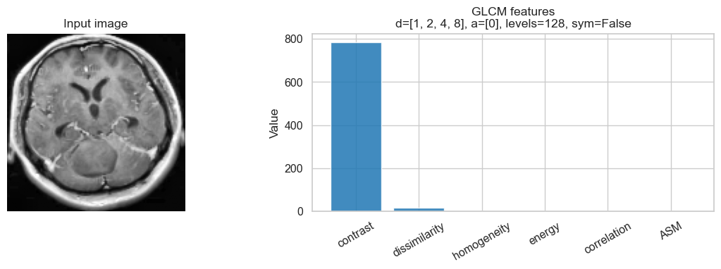

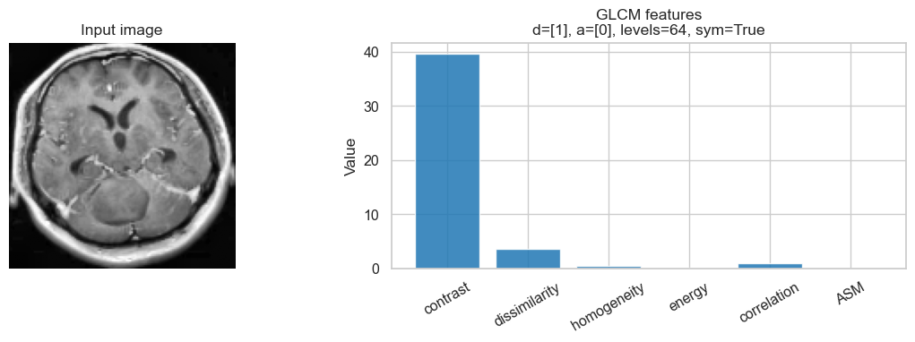

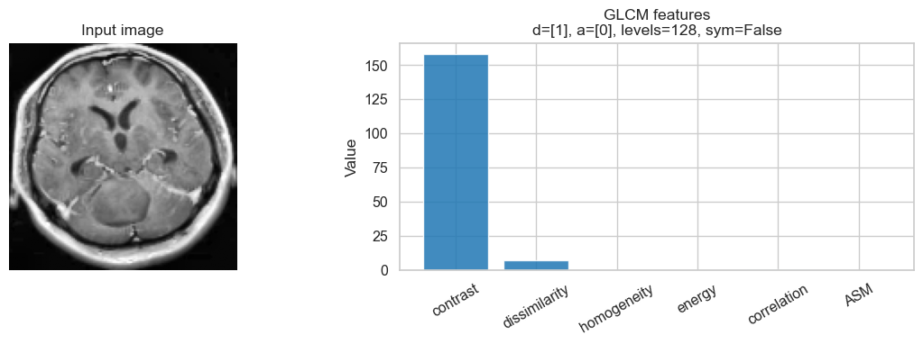

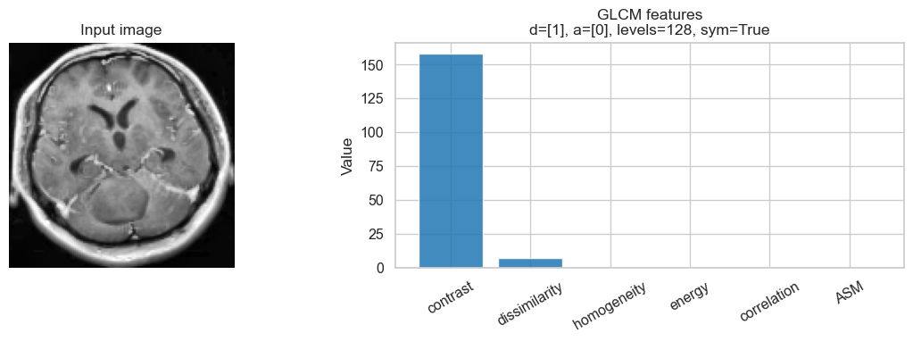

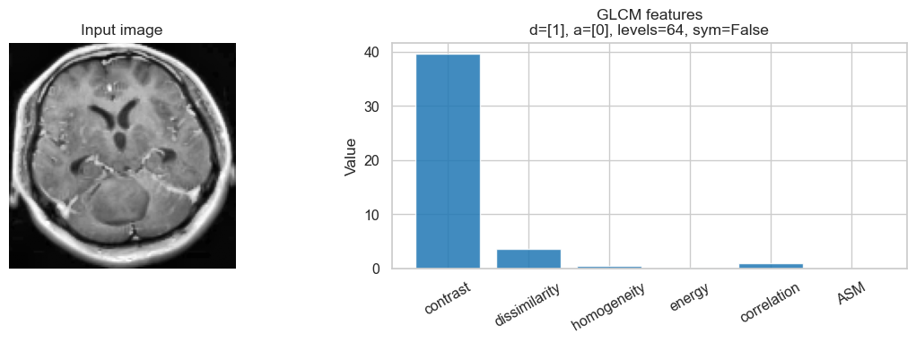

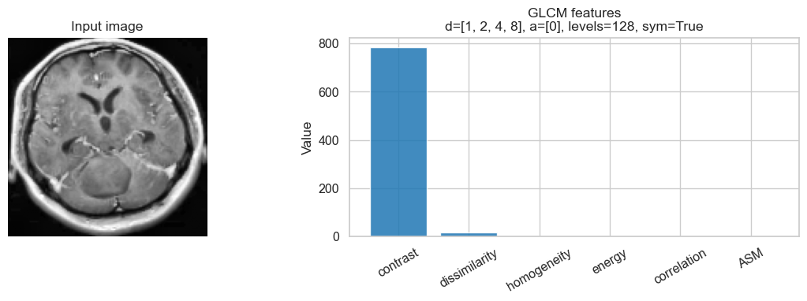

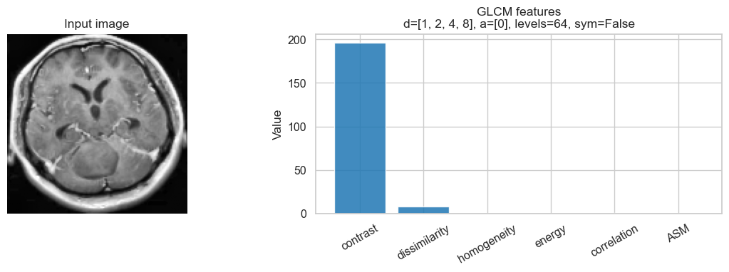

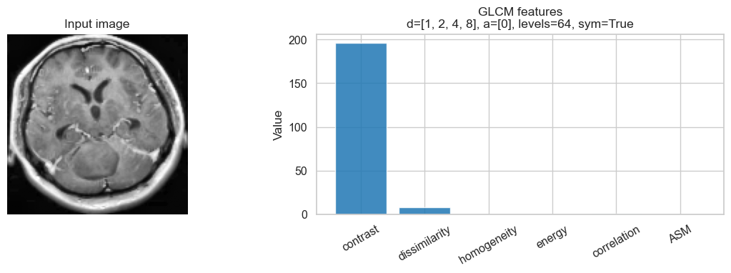

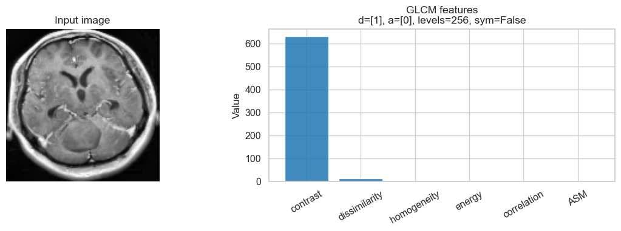

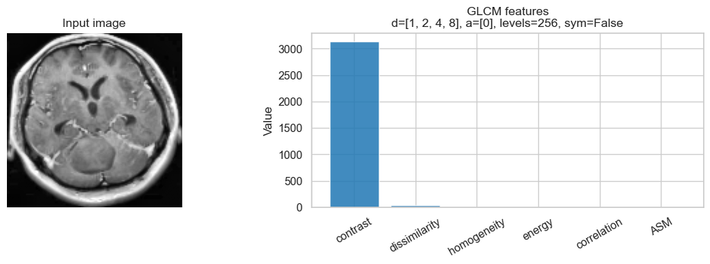

```python
from ast import literal_eval

def _print_glcm_best(header):
    print(header)
    print(f"  distances : {BEST_GLCM_DIST}")
    print(f"  angles    : {BEST_GLCM_ANG}")
    print(f"  levels    : {BEST_GLCM_LVL}")
    print(f"  symmetric : {BEST_GLCM_SYM}")
    print(f"  score     : {glcm_df.iloc[0]['score']:.4f}")

_glcm_cache = load_phase1_scan("glcm", GLCM_GRID)
if _glcm_cache is not None:
    glcm_df = _glcm_cache["df"]
    _apply_glcm_best_from_df()
    _print_glcm_best("\n✓ Best GLCM config (from cache):")
elif RUN_PHASE1_SCANS:
    print("Scanning GLCM parameter space …")
    glcm_rows = []

    configs = list(itertools.product(
        GLCM_GRID["distances"],
        GLCM_GRID["angles"],
        GLCM_GRID["levels"],
        GLCM_GRID["symmetric"],
    ))
    print(f"Total GLCM configurations: {len(configs)}")

    for dist, ang, lvl, sym in tqdm(configs, desc="GLCM"):
        label = (f"d={dist} a={len(ang)}ang "
                 f"l={lvl} sym={sym}")
        try:
            X_feat = extract_glcm(X_train_raw, dist, ang, lvl, sym)
            metrics = evaluate_features(X_feat, y_train)
            glcm_rows.append({
                "distances":  str(dist),
                "n_distances": len(dist),
                "angles":     str([round(a,3) for a in ang]),
                "n_angles":   len(ang),
                "levels":     lvl,
                "symmetric":  sym,
                "n_features": X_feat.shape[1],
                "label":      label,
                **metrics,
            })
        except Exception as e:
            print(f"  SKIP {label}: {e}")

    glcm_df = pd.DataFrame(glcm_rows)

    mms = MinMaxScaler()
    glcm_df["FDR_n"]  = mms.fit_transform(glcm_df[["FDR"]])
    glcm_df["MI_n"]   = mms.fit_transform(glcm_df[["MI"]])
    glcm_df["DBI_n"]  = 1 - mms.fit_transform(glcm_df[["DBI"]])
    glcm_df["score"]  = (glcm_df["FDR_n"] + glcm_df["MI_n"] + glcm_df["DBI_n"]) / 3
    glcm_df = glcm_df.sort_values("score", ascending=False).reset_index(drop=True)

    print("\nTop 10 GLCM configurations:")
    display(glcm_df[["distances","n_angles","levels","symmetric",
                     "n_features","FDR","MI","DBI","score"]].head(10).round(4))

    _apply_glcm_best_from_df()
    _print_glcm_best("\n✓ Best GLCM config:")
    save_phase1_scan("glcm", GLCM_GRID, glcm_df)
else:
    _print_glcm_best("\n✓ Best GLCM config (restored from bundle):")

GLCM_PROPS = ["contrast", "dissimilarity", "homogeneity", "energy", "correlation", "ASM"]

def glcm_features_for_one_image(img, distances, angles, levels, symmetric):
    q = np.clip(np.floor(img * levels), 0, levels - 1).astype(np.uint8)
    glcm = graycomatrix(
        q,
        distances=distances,
        angles=angles,
        levels=levels,
        symmetric=symmetric,
        normed=True,
    )
    return np.array([graycoprops(glcm, p).mean() for p in GLCM_PROPS], dtype=np.float32)

if RUN_PHASE1_VIZ:
    def plot_glcm_features_on_image(img, distances, angles, levels, symmetric, title_suffix=""):
        vals = glcm_features_for_one_image(img, distances, angles, levels, symmetric)
        fig, axes = plt.subplots(1, 2, figsize=(12, 4))
        axes[0].imshow(img, cmap="gray")
        axes[0].set_title("Input image")
        axes[0].axis("off")
        axes[1].bar(GLCM_PROPS, vals, color="tab:blue", alpha=0.85)
        axes[1].set_title("GLCM features" + (f"\n{title_suffix}" if title_suffix else ""))
        axes[1].set_ylabel("Value")
        axes[1].tick_params(axis="x", rotation=30)
        plt.tight_layout()
        plt.show()

    sample_idx = 0
    sample_img = X_train_raw[sample_idx]
    glcm_to_plot = glcm_df.head(10)
    for _, row in glcm_to_plot.iterrows():
        dist = literal_eval(row["distances"])
        ang  = literal_eval(row["angles"])
        lvl  = int(row["levels"])
        sym  = bool(row["symmetric"])
        label = f"d={dist}, a={ang}, levels={lvl}, sym={sym}"
        plot_glcm_features_on_image(sample_img, dist, ang, lvl, sym, title_suffix=label)
```

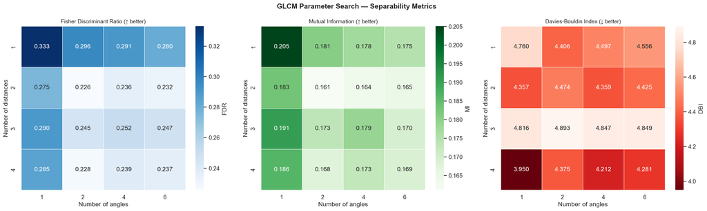

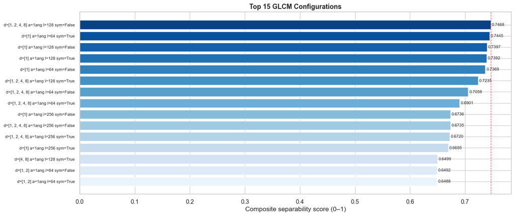

```
Saved: glcm_param_search.png, glcm_top15.png
```

```python
# ── GLCM visualisation ─────────────────────────────────────────────────────
fig, axes = plt.subplots(1, 3, figsize=(20, 6))
fig.suptitle("GLCM Parameter Search — Separability Metrics", fontsize=14, fontweight="bold")

metrics_plot = [("FDR","Fisher Discriminant Ratio (↑ better)","Blues"),
                ("MI", "Mutual Information (↑ better)",       "Greens"),
                ("DBI","Davies-Bouldin Index (↓ better)",     "Reds")]

for ax, (met, title, cmap) in zip(axes, metrics_plot):
    # Pivot: group by n_distances vs n_angles, average over levels & symmetric
    piv = glcm_df.groupby(["n_distances","n_angles"])[met].mean().unstack()
    if met == "DBI":
        # For DBI invert colour (lower=better should be dark)
        sns.heatmap(piv, ax=ax, cmap=cmap+"_r", annot=True, fmt=".3f",
                    linewidths=0.5, cbar_kws={"label": met})
    else:
        sns.heatmap(piv, ax=ax, cmap=cmap, annot=True, fmt=".3f",
                    linewidths=0.5, cbar_kws={"label": met})
    ax.set_title(title, fontsize=11)
    ax.set_xlabel("Number of angles")
    ax.set_ylabel("Number of distances")

plt.tight_layout()
plt.savefig(OUTPUT_DIR / "glcm_param_search.png", dpi=120, bbox_inches="tight")
plt.show()

# ── Score bar chart: top 15 configs ───────────────────────────────────────
fig, ax = plt.subplots(figsize=(14, 6))
top15 = glcm_df.head(15)
bars = ax.barh(range(15)[::-1], top15["score"],
               color=sns.color_palette("Blues_r", 15))
ax.set_yticks(range(15)[::-1])
ax.set_yticklabels(top15["label"], fontsize=8)
ax.set_xlabel("Composite separability score (0–1)")
ax.set_title("Top 15 GLCM Configurations", fontsize=13, fontweight="bold")
ax.bar_label(bars, fmt="%.4f", fontsize=8, padding=2)
ax.axvline(top15["score"].max(), color="red", ls="--", lw=1, alpha=0.6)
plt.tight_layout()
plt.savefig(OUTPUT_DIR / "glcm_top15.png", dpi=120, bbox_inches="tight")
plt.show()
print("Saved: glcm_param_search.png, glcm_top15.png")
```

### 7. Phase 1B — LBP Parameter Selection

```
Loaded LBP scan from cache: lbp_d7724dd503f4623a.joblib (saved 2026-06-05T00:59:34.419043+00:00)

✓ Best LBP config (from cache):
  P      : 12
  R      : 1
  method : uniform
  score  : 0.9906
```

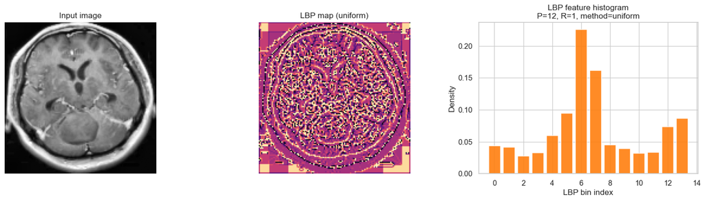

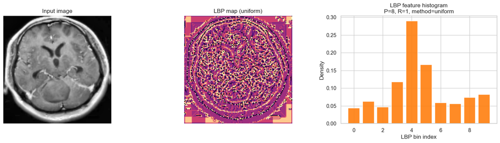

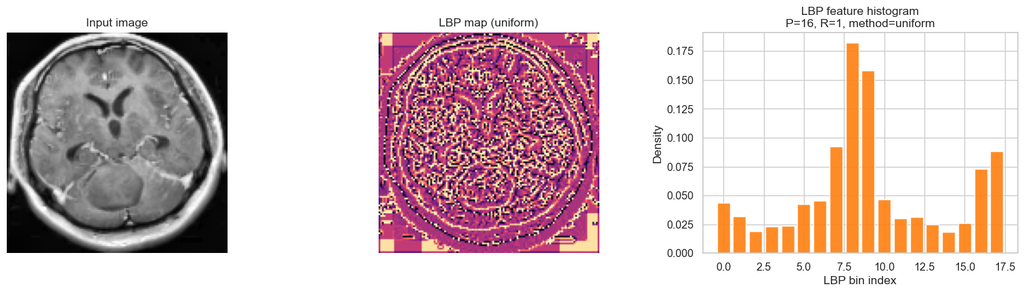

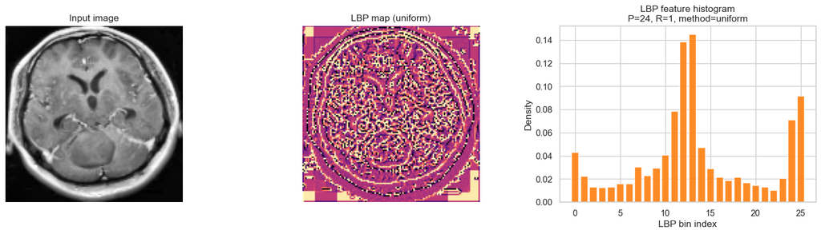

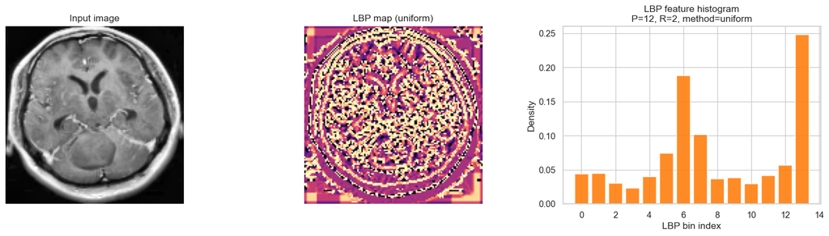

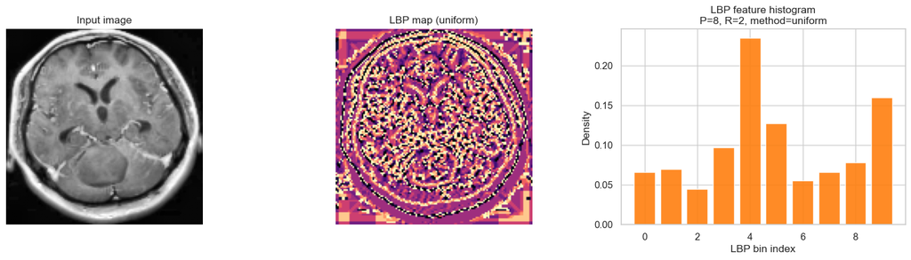

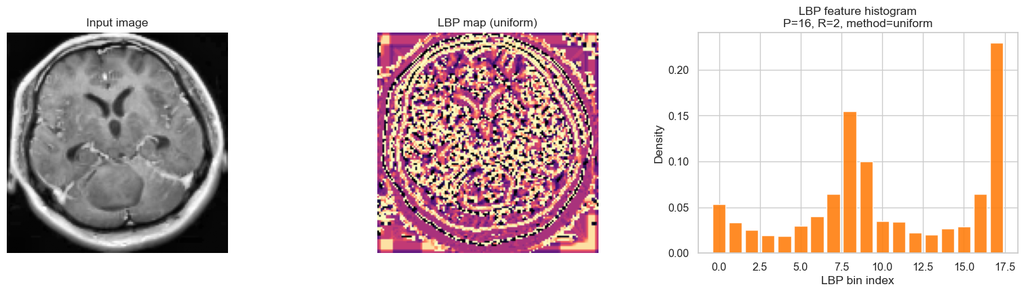

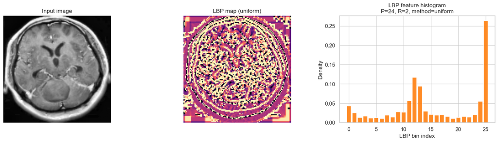

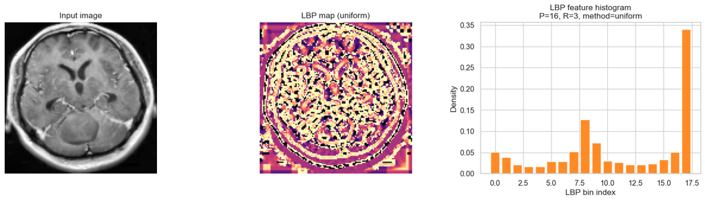

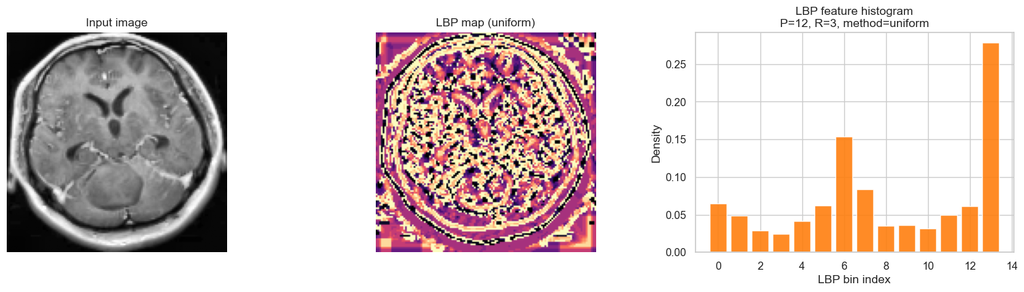

```python
_lbp_cache = load_phase1_scan("lbp", LBP_GRID)
if _lbp_cache is not None:
    lbp_df = _lbp_cache["df"]
    _apply_lbp_best_from_df()
    print("\n✓ Best LBP config (from cache):")
    print(f"  P      : {BEST_LBP_P}")
    print(f"  R      : {BEST_LBP_R}")
    print(f"  method : {BEST_LBP_METHOD}")
    print(f"  score  : {lbp_df.iloc[0]['score']:.4f}")
elif RUN_PHASE1_SCANS:
    print("Scanning LBP parameter space …")
    lbp_rows = []

    configs_lbp = list(itertools.product(
        LBP_GRID["P"],
        LBP_GRID["R"],
        LBP_GRID["method"],
    ))
    print(f"Total LBP configurations: {len(configs_lbp)}")

    for P, R, method in tqdm(configs_lbp, desc="LBP"):
        label = f"P={P:2d} R={R} method={method}"
        try:
            X_feat = extract_lbp(X_train_raw, P, R, method)
            metrics = evaluate_features(X_feat, y_train)
            lbp_rows.append({
                "P": P, "R": R, "method": method,
                "n_features": X_feat.shape[1],
                "label": label,
                **metrics,
            })
        except Exception as e:
            print(f"  SKIP {label}: {e}")

    lbp_df = pd.DataFrame(lbp_rows)

    mms = MinMaxScaler()
    lbp_df["FDR_n"] = mms.fit_transform(lbp_df[["FDR"]])
    lbp_df["MI_n"]  = mms.fit_transform(lbp_df[["MI"]])
    lbp_df["DBI_n"] = 1 - mms.fit_transform(lbp_df[["DBI"]])
    lbp_df["score"] = (lbp_df["FDR_n"] + lbp_df["MI_n"] + lbp_df["DBI_n"]) / 3
    lbp_df = lbp_df.sort_values("score", ascending=False).reset_index(drop=True)

    print("\nTop 10 LBP configurations:")
    display(lbp_df[["P","R","method","n_features","FDR","MI","DBI","score"]].head(10).round(4))

    _apply_lbp_best_from_df()
    print(f"\n✓ Best LBP config:")
    print(f"  P      : {BEST_LBP_P}")
    print(f"  R      : {BEST_LBP_R}")
    print(f"  method : {BEST_LBP_METHOD}")
    print(f"  score  : {lbp_df.iloc[0]['score']:.4f}")
    save_phase1_scan("lbp", LBP_GRID, lbp_df)
else:
    print("LBP scans skipped — using Phase 1 bundle.")
    print(f"\n✓ Best LBP config (restored):")
    print(f"  P      : {BEST_LBP_P}")
    print(f"  R      : {BEST_LBP_R}")
    print(f"  method : {BEST_LBP_METHOD}")
    print(f"  score  : {lbp_df.iloc[0]['score']:.4f}")

def lbp_features_for_one_image(img, P, R, method):
    lbp = local_binary_pattern(img, P=P, R=R, method=method)
    MAX_LBP_BINS = 4096
    if method in ("uniform", "nri_uniform"):
        n_bins = P + 2
        hist_range = (0, n_bins)
    else:
        full_bins = 2 ** P
        n_bins = min(full_bins, MAX_LBP_BINS)
        hist_range = (0, full_bins)
    hist, _ = np.histogram(lbp.ravel(), bins=n_bins, range=hist_range, density=True)
    return lbp, hist.astype(np.float32)

if RUN_PHASE1_VIZ:
    def plot_lbp_features_on_image(img, P, R, method, title_suffix=""):
        lbp_img, hist = lbp_features_for_one_image(img, P, R, method)
        fig, axes = plt.subplots(1, 3, figsize=(16, 4.5))
        axes[0].imshow(img, cmap="gray")
        axes[0].set_title("Input image")
        axes[0].axis("off")
        axes[1].imshow(lbp_img, cmap="magma")
        axes[1].set_title(f"LBP map ({method})")
        axes[1].axis("off")
        axes[2].bar(np.arange(len(hist)), hist, color="tab:orange", alpha=0.9)
        axes[2].set_title("LBP feature histogram" + (f"\n{title_suffix}" if title_suffix else ""))
        axes[2].set_xlabel("LBP bin index")
        axes[2].set_ylabel("Density")
        plt.tight_layout()
        plt.show()

    sample_idx = 0
    sample_img = X_train_raw[sample_idx]
    lbp_to_plot = lbp_df.head(10)
    for _, row in lbp_to_plot.iterrows():
        P = int(row["P"])
        R = int(row["R"])
        method = str(row["method"])
        label = f"P={P}, R={R}, method={method}"
        plot_lbp_features_on_image(sample_img, P, R, method, title_suffix=label)
```

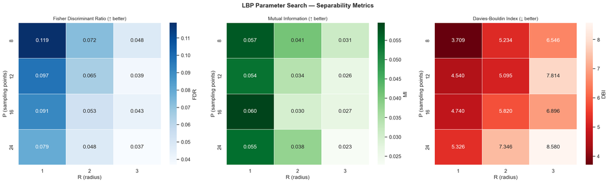

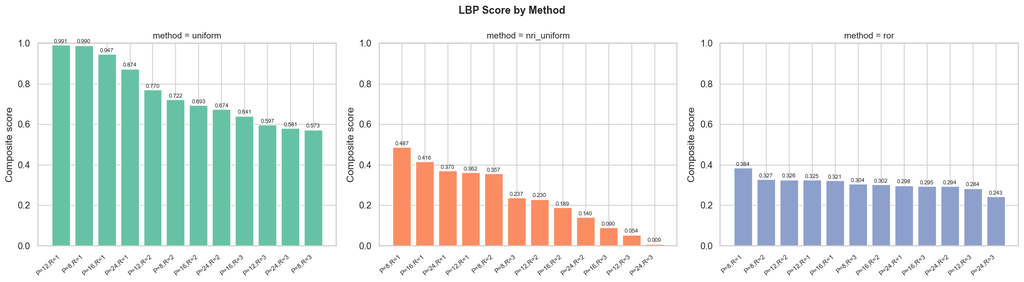

```
Saved: lbp_param_search.png, lbp_by_method.png
```

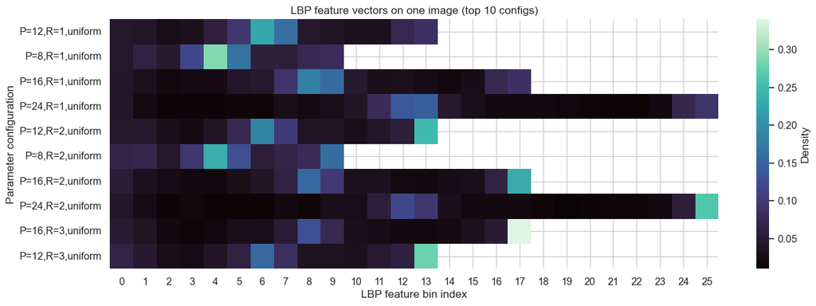

```
Saved: lbp_feature_vectors_top10.png
```

```python
# ── LBP visualisation ─────────────────────────────────────────────────────
fig, axes = plt.subplots(1, 3, figsize=(20, 6))
fig.suptitle("LBP Parameter Search — Separability Metrics", fontsize=14, fontweight="bold")

for ax, (met, title, cmap) in zip(axes, [
        ("FDR","Fisher Discriminant Ratio (↑ better)","Blues"),
        ("MI", "Mutual Information (↑ better)",       "Greens"),
        ("DBI","Davies-Bouldin Index (↓ better)",     "Reds")]):

    piv = lbp_df.groupby(["P","R"])[met].mean().unstack()
    inv = (met == "DBI")
    sns.heatmap(piv, ax=ax, cmap=cmap+"_r" if inv else cmap,
                annot=True, fmt=".3f", linewidths=0.5,
                cbar_kws={"label": met})
    ax.set_title(title, fontsize=11)
    ax.set_xlabel("R (radius)")
    ax.set_ylabel("P (sampling points)")

plt.tight_layout()
plt.savefig(OUTPUT_DIR / "lbp_param_search.png", dpi=120, bbox_inches="tight")
plt.show()

# ── Score by method ────────────────────────────────────────────────────────
fig, axes = plt.subplots(1, len(LBP_GRID["method"]), figsize=(18, 5), sharey=False)
fig.suptitle("LBP Score by Method", fontsize=13, fontweight="bold")
method_colors = sns.color_palette("Set2", len(LBP_GRID["method"]))

for ax, (method, color) in zip(axes, zip(LBP_GRID["method"], method_colors)):
    sub = lbp_df[lbp_df["method"]==method].sort_values("score", ascending=False)
    bars = ax.bar(range(len(sub)), sub["score"], color=color, edgecolor="white")
    ax.set_xticks(range(len(sub)))
    ax.set_xticklabels([f"P={r['P']},R={r['R']}" for _, r in sub.iterrows()],
                       rotation=40, ha="right", fontsize=8)
    ax.set_title(f"method = {method}", fontsize=11)
    ax.set_ylim(0, 1)
    ax.set_ylabel("Composite score")
    ax.bar_label(bars, fmt="%.3f", fontsize=7, padding=1)

plt.tight_layout()
plt.savefig(OUTPUT_DIR / "lbp_by_method.png", dpi=120, bbox_inches="tight")
plt.show()
print("Saved: lbp_param_search.png, lbp_by_method.png")

# ── Optional compact view: top-LBP configs vs feature bins (sample image) ──
sample_idx = 0
sample_img = X_train_raw[sample_idx]
lbp_top = lbp_df.head(10)

max_bins = int(lbp_top["n_features"].max())
feature_matrix = np.full((len(lbp_top), max_bins), np.nan, dtype=np.float32)
row_labels = []

for i, (_, row) in enumerate(lbp_top.iterrows()):
    P = int(row["P"])
    R = int(row["R"])
    method = str(row["method"])
    _, hist = lbp_features_for_one_image(sample_img, P, R, method)
    feature_matrix[i, :len(hist)] = hist
    row_labels.append(f"P={P},R={R},{method}")

plt.figure(figsize=(14, 5))
sns.heatmap(feature_matrix, cmap="mako", cbar_kws={"label": "Density"})
plt.yticks(np.arange(len(row_labels)) + 0.5, row_labels, rotation=0)
plt.xlabel("LBP feature bin index")
plt.ylabel("Parameter configuration")
plt.title("LBP feature vectors on one image (top 10 configs)")
plt.tight_layout()
plt.savefig(OUTPUT_DIR / "lbp_feature_vectors_top10.png", dpi=120, bbox_inches="tight")
plt.show()
print("Saved: lbp_feature_vectors_top10.png")
```